# New insights on social media metrics: examining the relationship between universities’ academic reputation and Wikipedia attention

Wenceslao Arroyo-Machado, Adrián A. Díaz-Faes, Rodrigo Costas

30 April, 2022

This is the [R Markdown](http://rmarkdown.rstudio.com) Notebook created for the STI conference paper titled ‘New insights on social media metrics: examining the relationship between universities’ academic reputation and Wikipedia attentio’. Notebook and data are available at [GitHub](https://github.com/Wences91/wikipedia_universities).

```r
library(dplyr)
require(ggrepel)
library(corrplot)
library(wesanderson)
library(ggplot2)
library(ggpubr)
library(patchwork)
```

## Preprocessing

The full data.frame of universities indicators and countries are imported. A minor preprocessing is necessary to incorporate geographic information into the data.

```r
wiki_univ <- read.delim('results/wiki_univ.tsv', check.names = FALSE)
name_countries <- read.delim('data/countries.tsv')
continents <- read.delim('data/continents.tsv', check.names = FALSE)
```

Three data.frame are merged.

```r
wiki_univ <- inner_join(wiki_univ,
                        name_countries[,c('country_iso_num_code',
                                          'univ_name',
                                          'iso_name',
                                          'country_iso_alpha3_code')],
                        by='country_iso_num_code')

wiki_univ <- left_join(wiki_univ,
                       continents[,c('ISO-alpha3 Code',
                                     'Continent')],
                       by=c('country_iso_alpha3_code'='ISO-alpha3 Code'))
```

```r
as.data.frame(table(wiki_univ$Continent))
```

```
##            Var1 Freq
## 1        Africa   27
## 2          Asia  485
## 3        Europe  387
## 4 North America  236
## 5       Oceania   39
## 6 South America   41
```

Continent information is transformed into a categorical variable.

```r
wiki_univ$Continent <- as.integer(as.factor(wiki_univ$Continent))
```

A new data.frame is created with the with the frequency of universities per country.

```r
countries <- as.data.frame(table(wiki_univ$univ_name),
                           stringsAsFactors = FALSE)

names(countries) <- c('country', 'universities')
countries <- countries[order(countries$universities, decreasing = TRUE),]
```

China and United States are the countries with the highest number of universities in the Leiden Ranking.

```r
head(countries, 10)
```

```
##           country universities
## 9           China          216
## 67  United States          200
## 66 United Kingdom           61
## 20        Germany           54
## 30          Japan           54
## 56    South Korea           46
## 29          Italy           42
## 57          Spain           42
## 25          India           38
## 26           Iran           36
```

Since we want to differentiate between all universities and only those of the core Anglo-Saxon countries, we create a new variable (dummy).

```r
wiki_univ$anglo <- 0
wiki_univ$anglo[which(wiki_univ$univ_name %in% c('United States', 'United Kingdom', 'Canada', 'Australia', 'New Zealand', 'Ireland'))] <- 1
```

```r
table(wiki_univ$anglo)
```

```
##
##   0   1
## 879 336
```

As there are a lot of columns in the Wikipedia universities data.frame, we identify the most relevant for the analysis.

```r
variables <- c(
  'publications'
  ,'top_pubs'
  ,'pp_top'
  ,'collaboration'
  ,'oa'
  ,'univ_age'
  ,'len'
  ,'page_edits'
  ,'views'
  ,'langlinks'
  ,'page_age'
)
```

We created a new data.frame with the average value of indicators by country. Only countries with more than 10 universities are considered.

```r
df_group <- wiki_univ
df_group[which(df_group$univ_name %in% countries$country[which(countries$universities <= 10)]), c('univ_name')] <- ''
df_group$universities <- 1
df_group <- df_group[,c('univ_name', 'universities', variables)] %>%
  group_by(univ_name) %>%
  summarise(across(variables, mean, na.rm=TRUE), universities=sum(universities))
```

```r
df_group[order(df_group$universities, decreasing = TRUE),]
```

```
## # A tibble: 21 × 13
##    univ_name    publications top_pubs pp_top collaboration    oa univ_age    len
##    <chr>               <dbl>    <dbl>  <dbl>         <dbl> <dbl>    <dbl>  <dbl>
##  1 "China"             8024.     918. 0.105          6019. 2905.     88.9 14095.
##  2 "United Sta…       10695.    1796. 0.149          8848. 6723.    147.  93359.
##  3 ""                  6419.     807. 0.110          5347. 3465.    139.  31176.
##  4 "United Kin…        9448.    1679. 0.161          8141. 8049.    163.  77672.
##  5 "Germany"           8322.    1217. 0.137          7075. 4768.    213.  27439.
##  6 "Japan"             5766.     495. 0.0758         4704. 3055.    104.  17885.
##  7 "South Kore…        6493.     532. 0.0769         5071. 2795.     87.2 18167.
##  8 "Italy"             7596.     980. 0.128          6559. 4116.    330.  16770.
##  9 "Spain"             5305.     609. 0.109          4433. 3014.    241.  14008.
## 10 "India"             3350.     278. 0.0835         2120.  836.     74.1 30990.
## # … with 11 more rows, and 5 more variables: page_edits <dbl>, views <dbl>,
## #   langlinks <dbl>, page_age <dbl>, universities <dbl>
```

As can be seen, Anglo-Saxon universities cath more page views.

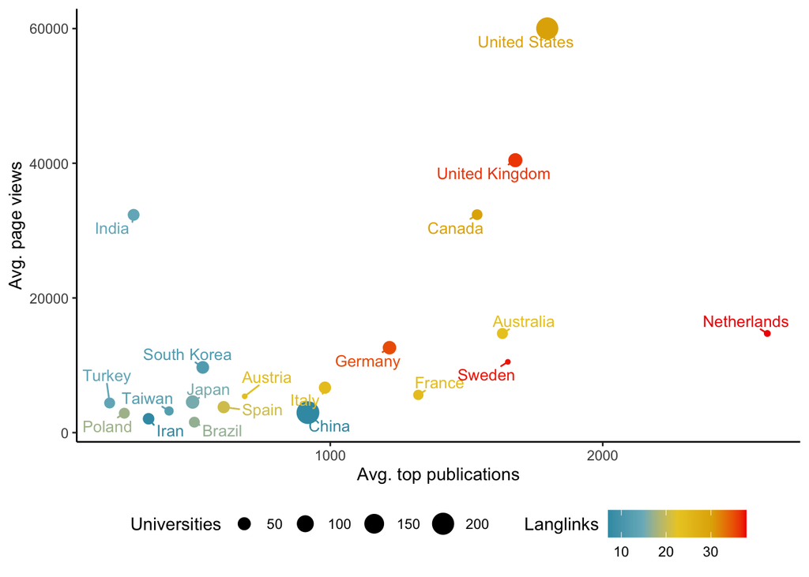

```r
ggplot(data=df_group[which(df_group$univ_name!=''),], aes(x=top_pubs, y=views, color=langlinks, size=universities))+
  geom_point()+
  geom_text_repel(aes(label = univ_name),
                  size = 3.5,  min.segment.length = 0) +
  scale_color_gradientn(colors=wes_palette('Zissou1'))+
  labs(x='Avg. top publications', y='Avg. page views', color='Langlinks', size='Universities')+
  theme_classic()+
  theme(legend.position = 'bottom')+
  guides(colour=guide_colourbar(title.vjust = 0.8))
```

## Correlations

Spearman’s correlations are calculated using all universities.

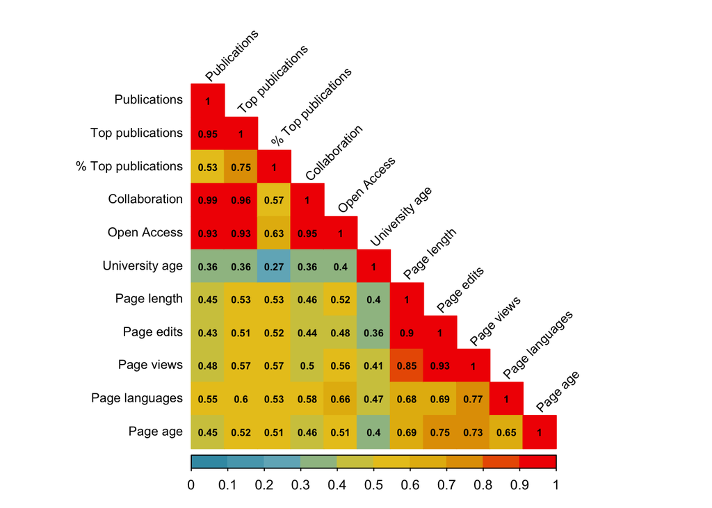

```r
variables_ren <- c(
  'Publications'
  ,'Top publications'
  ,'% Top publications'
  ,'Collaboration'
  ,'Open Access'
  ,'University age'
  ,'Page length'
  ,'Page edits'
  ,'Page views'
  ,'Page languages'
  ,'Page age'
)

wiki_univ_cor <- wiki_univ[, variables]
names(wiki_univ_cor) <- variables_ren

#png('figures/correlations_general.png', width = 800, height = 800, res=150)
corrplot(cor(wiki_univ_cor, use = 'complete.obs', method='spearman'), method='color', col=wes_palette('Zissou1', 10, type = 'continuous'),
         type='lower',
         is.corr = FALSE, col.lim = c(0,1),
         addCoef.col = 'black',
         tl.col='black', tl.srt=45,
         diag=T, number.cex = 0.6, tl.cex = 0.75
)
```

Spearman’s correlations are calculated using only Anglo-Saxon universities.

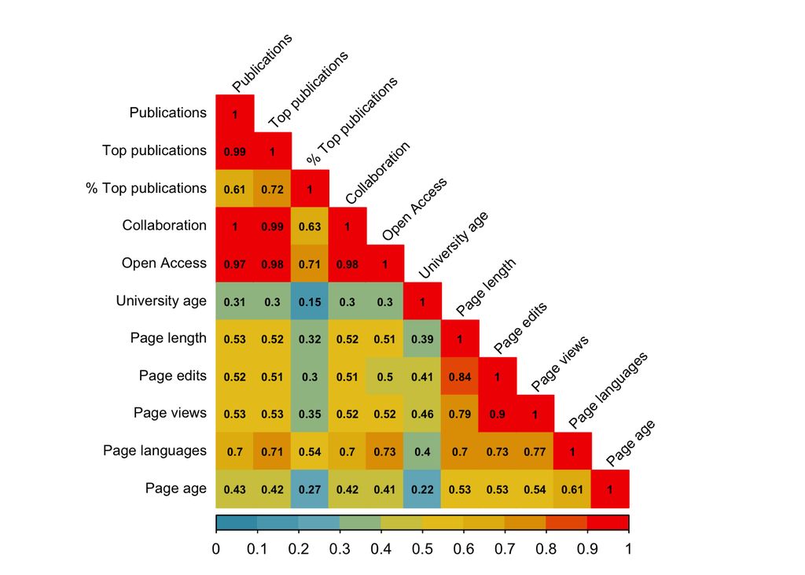

```r
wiki_univ_cor <- wiki_univ[which(wiki_univ$anglo==1), variables]
names(wiki_univ_cor) <- variables_ren

#png('figures/correlations_anglo.png', width = 800, height = 800, res=150)
corrplot(cor(wiki_univ_cor, use = 'complete.obs', method='spearman'), method='color', col=wes_palette('Zissou1', 10, type = 'continuous'),
         type='lower',
         is.corr = FALSE, col.lim = c(0,1),
         addCoef.col = 'black',
         tl.col='black', tl.srt=45,
         diag=T, number.cex = 0.6, tl.cex = 0.75
)
```

## Scatter and density plot

When looking at the relationship between page views and top publications we find two different phenomena that have to do with the language of the university’s country.

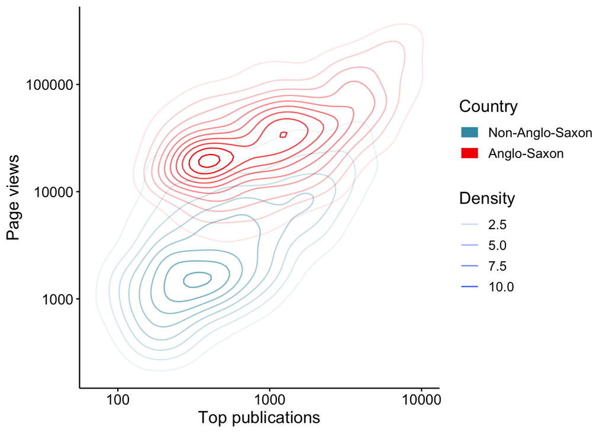

```r
wiki_univ$anglo <- factor(wiki_univ$anglo, levels=c(0,1), labels=c('Non-Anglo-Saxon', 'Anglo-Saxon'))

ggplot(data=wiki_univ, aes(x=top_pubs, y=views, color=anglo))+
  stat_density_2d(aes(alpha = ..piece..))+
  scale_x_log10()+
  scale_y_log10()+
  labs(x='Top publications', y='Page views', color='Country', fill='Country', alpha='Density')+
  scale_fill_manual(values = wes_palette(name = 'Zissou1')[c(1,5)])+
  scale_color_manual(values = wes_palette(name = 'Zissou1')[c(1,5)])+
  theme_classic()+
  theme(legend.position = 'right',
        legend.direction = 'vertical',
        text=element_text(family='Arial', size=14, color='black'),
        axis.text=element_text(color='black', size=12),
        axis.ticks=element_line(color='black'),
        legend.text = element_text(size=11))+
  guides(color = guide_legend(override.aes = aes(label = '', size = 4)))
```

It is clear how universities from Anglo-Saxon countries get more page views as well as they have more top publication but not by such a large difference.

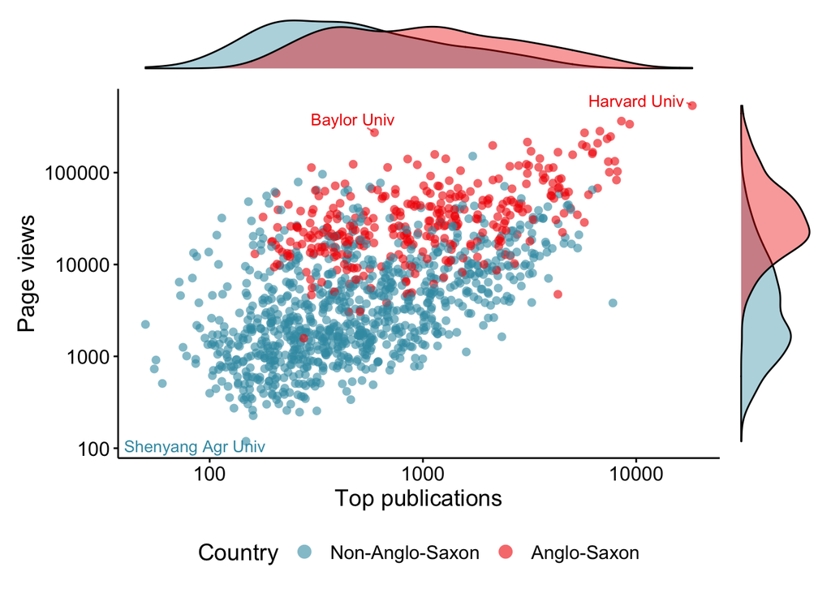

```r
plot_1 <- ggplot(data=wiki_univ, aes(x=top_pubs, y=views, fill=anglo))+
  geom_point(size=2.5, alpha=.6, shape=21, stroke=0)+
  geom_text_repel(aes(label = university,
                      color=anglo),
                  size = 3.5, min.segment.length = 0, segment.alpha=.6) +

  labs(x='Top publications', y='Page views', color='Country', fill='Country')+
  scale_fill_manual(values = wes_palette(name = 'Zissou1')[c(1,5)])+
  scale_color_manual(values = wes_palette(name = 'Zissou1')[c(1,5)])+
  scale_x_log10()+
  scale_y_log10()+
  theme_classic()+
  theme(legend.position = 'bottom',
        text=element_text(family='Arial', size=14, color='black'),
        axis.text=element_text(color='black', size=12),
        axis.ticks=element_line(color='black'),
        legend.text = element_text(size=11.5))+
  guides(color = guide_legend(override.aes = aes(label = '', size = 4)))



 dens_1 <- ggplot(data=wiki_univ, aes(x=top_pubs, fill=anglo)) +
  geom_density(alpha = 0.4) +
   scale_x_log10()+
  scale_fill_manual(values = wes_palette(name = 'Zissou1')[c(1,5)]) +
  theme_void() +
  theme(legend.position = "none")

 dens_2 <- ggplot(data=wiki_univ, aes(x=views, fill=anglo)) +
   geom_density(alpha = 0.4) +
  scale_x_log10()+
   scale_fill_manual(values = wes_palette(name = 'Zissou1')[c(1,5)])+
   theme_void() +
   theme(legend.position = "none") +
   coord_flip()


 dens_1 + plot_spacer() + plot_1 + dens_2 +
   plot_layout(ncol = 2, nrow = 2, widths = c(8, 1), heights = c(1, 7))
```

```r
 #ggsave('figures/scatterplot_density.png', width=11, height=6.5, dpi=300)
```